# ch08_04_sonar_analysis02

### 분류(classification) 문제 실습 - 항구의 기뢰 찾기

### 학습 목표

- 데이터을 전처리 후, 이에 대한 머신러닝 모델을 만들어봅니다.
- 모델 비교에 대해 이해해 봅니다.
- 모델 평가에 대해 기본 이해해 봅니다.

### 학습 내용

- 주어진 데이터를 적절한 비율로 나누어보기
- knn 모델 만들어보기
- 의사결정 트리 모델을 만들어보기
- 모델 평가해 보기
- 데이터 셋 : UC Irvine Data Repository
  - https://archive.ics.uci.edu/ml/datasets.php
  - Connectionist Bench (Sonar, Mines vs. Rocks) Data Set
    - https://archive.ics.uci.edu/ml/datasets/Connectionist+Bench+%28Sonar%2C+Mines+vs.+Rocks%29
    - sonar.all-data

### 데이터 설명

- 데이터 셋 특성 : 다변수
- 행의 수 : 208개
- 열의 수 : 60개
- 데이터 설명
  - 다양한 각도와 다양한 조건에서 금속 실린더에서 수중 음파 탐지기 신호를 통해 얻은 다양한 패턴이 포함되어 있음.
  - 군사작전의 결과로 항구에 남아 있는 폭파되지 않은 기뢰를 찾기 위해 소나(Sonar, 수중 음파탐지기)를 이용할 수 있는지 확인하기 위한 어떤 실험으로 만들어짐.
  - 반 정도의 표본은 바위, 나마저 반은 기뢰 모양의 금속 원통을 나타냄.

### 01. 데이터 준비

```python
from urllib.request import urlopen
import sys
import pandas as pd
import matplotlib.pyplot as plt
import seaborn as sns
```

```python
target_url = "https://archive.ics.uci.edu/ml/machine-learning-databases/undocumented/connectionist-bench/sonar/sonar.all-data"
dat = pd.read_csv(target_url, header=None, prefix='V')
dat.head()
```

|  | V0 | V1 | V2 | V3 | V4 | V5 | V6 | V7 | V8 | V9 | ... | V51 | V52 | V53 | V54 | V55 | V56 | V57 | V58 | V59 | V60 |
| --- | --- | --- | --- | --- | --- | --- | --- | --- | --- | --- | --- | --- | --- | --- | --- | --- | --- | --- | --- | --- | --- |
| 0 | 0.0200 | 0.0371 | 0.0428 | 0.0207 | 0.0954 | 0.0986 | 0.1539 | 0.1601 | 0.3109 | 0.2111 | ... | 0.0027 | 0.0065 | 0.0159 | 0.0072 | 0.0167 | 0.0180 | 0.0084 | 0.0090 | 0.0032 | R |
| 1 | 0.0453 | 0.0523 | 0.0843 | 0.0689 | 0.1183 | 0.2583 | 0.2156 | 0.3481 | 0.3337 | 0.2872 | ... | 0.0084 | 0.0089 | 0.0048 | 0.0094 | 0.0191 | 0.0140 | 0.0049 | 0.0052 | 0.0044 | R |
| 2 | 0.0262 | 0.0582 | 0.1099 | 0.1083 | 0.0974 | 0.2280 | 0.2431 | 0.3771 | 0.5598 | 0.6194 | ... | 0.0232 | 0.0166 | 0.0095 | 0.0180 | 0.0244 | 0.0316 | 0.0164 | 0.0095 | 0.0078 | R |
| 3 | 0.0100 | 0.0171 | 0.0623 | 0.0205 | 0.0205 | 0.0368 | 0.1098 | 0.1276 | 0.0598 | 0.1264 | ... | 0.0121 | 0.0036 | 0.0150 | 0.0085 | 0.0073 | 0.0050 | 0.0044 | 0.0040 | 0.0117 | R |
| 4 | 0.0762 | 0.0666 | 0.0481 | 0.0394 | 0.0590 | 0.0649 | 0.1209 | 0.2467 | 0.3564 | 0.4459 | ... | 0.0031 | 0.0054 | 0.0105 | 0.0110 | 0.0015 | 0.0072 | 0.0048 | 0.0107 | 0.0094 | R |

5 rows × 61 columns

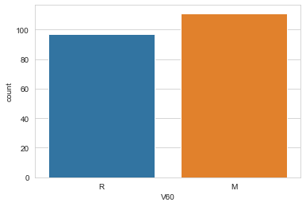

```python
sns.set_style('whitegrid')
sns.countplot(x='V60', data=dat)
```

```python
dat['target']=dat['V60']
dat.columns
```

[output not shown]

```python
### 인코딩 (R:0, M:1)
dat['target'] = dat['V60'].map( {'R':0, 'M':1 }  ).astype(int)
dat['target'].value_counts()
```

```
1    111
0     97
Name: target, dtype: int64
```

```python
dat.head()
```

[output not shown]

### 데이터 최종 전처리

- V60 열 삭제
- 입력 열 지정
- 출력(target) 열 지정
- 데이터 나누기(train_test_split)

```python
from sklearn.model_selection import train_test_split
```

```python
new_df = dat.drop("V60", axis='columns')
X_all = new_df.loc[:,'V0':'V59']  # V0~V59 열 선택
y = new_df['target']              # 'target' 열 선택

# test:10%, train:90%로 데이터 분리
X_train, X_test, y_train, y_test = train_test_split(X_all, y,
                                                   test_size=0.1,
                                                   random_state=0)

X_train.shape, X_test.shape, y_train.shape, y_test.shape
```

```
((187, 60), (21, 60), (187,), (21,))
```

```python
from sklearn.tree import DecisionTreeClassifier
from sklearn.neighbors import KNeighborsClassifier
```

```python
### 모델 선택 및 학습
model1 = DecisionTreeClassifier()
model1.fit(X_train, y_train)
model1.score(X_test, y_test)
```

```
0.7142857142857143
```

```python
### 모델 선택 및 학습
model2 = KNeighborsClassifier()
model2.fit(X_train, y_train)
model2.score(X_test, y_test)
```

```
0.8095238095238095
```

```python
### 최종 모델 선택 및 예측
last_model = KNeighborsClassifier()
last_model.fit(X_train, y_train)
pred = last_model.predict(X_test)
pred
```

```
array([1, 1, 1, 1, 1, 0, 1, 1, 0, 1, 0, 1, 0, 1, 0, 0, 1, 0, 0, 0, 1])
```

```python
### 최종 모델 평가
( sum(pred==y_test) / len(pred) ) * 100
```

```
80.95238095238095
```

- 최종 모델은 knn을 선택했고,
- 최종 모델 예측하여 평가 결과 : 81% 의 정확도를 갖는 모델을 만들었다.

### 실습 과제

- knn 모델의 k의 개수를 변경해 보며, 더 최적의 모델을 선택해 보자.
- V0~V59의 피처를 선택했는데, 이에 대한 일부만을 선택해 보며, 모델의 성능을 측정해 보자.